# Practical Machine Learning Assignment

Deon Jacobs

14 May 2017

## Human Activity Recognition Model Generation

### Overview

A machine learning model is generated from the PML dataset generously provided by http://groupware.les.inf.puc-rio.br/har:

Velloso, E.; Bulling, A.; Gellersen, H.; Ugulino, W.; Fuks, H. Qualitative Activity Recognition of Weight Lifting Exercises. Proceedings of 4th International Conference in Cooperation with SIGCHI (Augmented Human ’13) . Stuttgart, Germany: ACM SIGCHI, 2013.

Using measurements of several weight lifting exercises, models are tuned to discern which sets are done correctly, and which are not.

The supplied training and test datasets are loaded. The training set is again divided into a sub-training and sub-test set. Cross-validation is implemented on the sub-training and -test sets. Models are generated from the sub-training set, and the most accurate model selected from the sub-test set using the OsSE (Out of Sample Error) estimations. The selected ML model is then used to predict 20 various test cases.

### Required R-packages

```r
library(dplyr)
library(caret)
library(kernlab)
library(randomForest)
library(rpart)
library(gbm)
```

### Load PML Training and Test Dataset

```r
#Read training set data
setwd("C:\\Users\\Family\\Documents\\Data Science Specialisation\\Machine Learning")

# Read CSV into R
TrainData <- read.csv(file="pml-training.csv", header=TRUE, sep=",")
TestData <- read.csv(file="pml-testing.csv", header=TRUE, sep=",")
```

### Cross-Validation

Split original training set into sub-training and -test set. Transformations performed on new train set are also applied to test set:

```r
inTrain <- createDataPartition(y=TrainData$classe,p=0.7,list=FALSE)

newTrain <- TrainData[inTrain,]
newTest  <- TrainData[-inTrain,]

dim(newTrain)
```

```
## [1] 13737   160
```

```r
dim(newTest)
```

```
## [1] 5885  160
```

```r
dim(TestData)
```

```
## [1]  20 160
```

### Pre-Processing

Remove observed columns which will not contribute to model training and prediction: X, user_name, raw_timestamp_part_1, raw_timestamp_part_2, cvtd_timestamp, new_window, num_window.

```r
newTrain <- newTrain[,-c(1:7)]
newTest <- newTest[,-c(1:7)]
TestData <- TestData[,-c(1:7)]
```

Remove columns with row values containing NAs base on newTrain set

```r
naColumns <- sapply(newTrain,function(x) !any(is.na(x)))

newTrain <- newTrain[,naColumns]
newTest  <- newTest[,naColumns]
TestData  <- TestData[,naColumns]
```

Remove columns with near zero variance

```r
nzvColumns <- nearZeroVar(newTrain)

newTrain <- newTrain[,-nzvColumns]
newTest <- newTest[,-nzvColumns]
TestData <- TestData[,-nzvColumns]
```

Review of columns removed from the dataset

```r
dim(newTrain)
```

```
## [1] 13737    53
```

```r
dim(newTest)
```

```
## [1] 5885   53
```

```r
dim(TestData)
```

```
## [1] 20 53
```

### Model Selection

The exercise training data set does not suit linear regression prediction models.

Instead non-linear machine learning techniques are used to train and compare model performance: 1. Decision Tree 2. Random Forest 3. Gradient Boosting Machine

#### Decision Trees

Iteratively split variables into groups, evaluate “homogeneity” within each group. Split again if necessary.

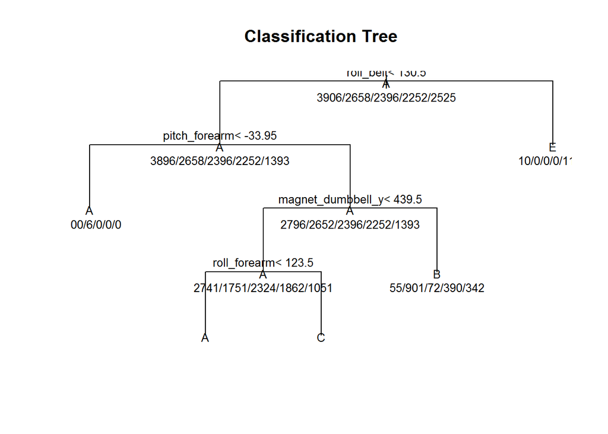

```r
set.seed(3640)
TreeModFit <- train(classe ~ .,method="rpart",data=newTrain)
plot(TreeModFit$finalModel,uniform=TRUE, main="Classification Tree")
text(TreeModFit$finalModel,use.n=TRUE, all=TRUE, cex=0.8)
```

```r
#Predict Classe variable from Training set ussing Decission Trees Model:
TreePredict <- predict(TreeModFit,newdata=newTest)
```

#### Random Forests

Bootstrap samples, at each split, bootstrap variables, grow multiple trees and vote.

```r
set.seed(3640)
RFControl <- trainControl(method="oob", number=10, repeats=1)
RFModelFit <- train(classe~.,method="rf",data=newTrain,trControl=RFControl)
#Predict Classe variable from Training set using Random Forest Model:
RFPredict <- predict(RFModelFit,newdata=newTest)
```

#### Boosting

Take lots of (possibly) weak predictors, weight them and add them up, get a stronger predictor.

```r
set.seed(3640)
BMControl <- trainControl(method="repeatedcv", number=10,repeats=1)
BModelFit <- train(classe~.,method="gbm",data=newTrain,verbose=FALSE,trControl=BMControl)
#Predict Classe variable from Training set using Boosting Model:
BPredict <- predict(BModelFit,newdata=newTest)
```

#### Model Accuracy Results

```r
confusionMatrix(TreePredict,newTest$classe)
```

```
## Confusion Matrix and Statistics
##
##           Reference
## Prediction    A    B    C    D    E
##          A 1515  478  482  430  160
##          B   26  385   36  178  144
##          C  129  276  508  356  279
##          D    0    0    0    0    0
##          E    4    0    0    0  499
##
## Overall Statistics
##
##                Accuracy : 0.494
##                  95% CI : (0.4811, 0.5068)
##     No Information Rate : 0.2845
##     P-Value [Acc > NIR] : < 2.2e-16
##
##                   Kappa : 0.3385
##  Mcnemar's Test P-Value : NA
##
## Statistics by Class:
##
##                      Class: A Class: B Class: C Class: D Class: E
## Sensitivity            0.9050  0.33802  0.49513   0.0000  0.46118
## Specificity            0.6319  0.91909  0.78596   1.0000  0.99917
## Pos Pred Value         0.4943  0.50065  0.32817      NaN  0.99205
## Neg Pred Value         0.9436  0.85262  0.88056   0.8362  0.89168
## Prevalence             0.2845  0.19354  0.17434   0.1638  0.18386
## Detection Rate         0.2574  0.06542  0.08632   0.0000  0.08479
## Detection Prevalence   0.5208  0.13067  0.26304   0.0000  0.08547
## Balanced Accuracy      0.7685  0.62855  0.64055   0.5000  0.73018
```

```r
confusionMatrix(RFPredict,newTest$classe)
```

```
## Confusion Matrix and Statistics
##
##           Reference
## Prediction    A    B    C    D    E
##          A 1672    8    0    0    0
##          B    0 1125    6    1    2
##          C    1    6 1016   21    1
##          D    0    0    4  941    7
##          E    1    0    0    1 1072
##
## Overall Statistics
##
##                Accuracy : 0.99
##                  95% CI : (0.9871, 0.9924)
##     No Information Rate : 0.2845
##     P-Value [Acc > NIR] : < 2.2e-16
##
##                   Kappa : 0.9873
##  Mcnemar's Test P-Value : NA
##
## Statistics by Class:
##
##                      Class: A Class: B Class: C Class: D Class: E
## Sensitivity            0.9988   0.9877   0.9903   0.9761   0.9908
## Specificity            0.9981   0.9981   0.9940   0.9978   0.9996
## Pos Pred Value         0.9952   0.9921   0.9722   0.9884   0.9981
## Neg Pred Value         0.9995   0.9971   0.9979   0.9953   0.9979
## Prevalence             0.2845   0.1935   0.1743   0.1638   0.1839
## Detection Rate         0.2841   0.1912   0.1726   0.1599   0.1822
## Detection Prevalence   0.2855   0.1927   0.1776   0.1618   0.1825
## Balanced Accuracy      0.9985   0.9929   0.9921   0.9870   0.9952
```

```r
confusionMatrix(BPredict,newTest$classe)
```

```
## Confusion Matrix and Statistics
##
##           Reference
## Prediction    A    B    C    D    E
##          A 1639   26    0    0    1
##          B   23 1086   37    8   10
##          C    7   25  970   45   13
##          D    5    0   18  906   14
##          E    0    2    1    5 1044
##
## Overall Statistics
##
##                Accuracy : 0.9592
##                  95% CI : (0.9538, 0.9641)
##     No Information Rate : 0.2845
##     P-Value [Acc > NIR] : < 2.2e-16
##
##                   Kappa : 0.9484
##  Mcnemar's Test P-Value : 3.213e-08
##
## Statistics by Class:
##
##                      Class: A Class: B Class: C Class: D Class: E
## Sensitivity            0.9791   0.9535   0.9454   0.9398   0.9649
## Specificity            0.9936   0.9836   0.9815   0.9925   0.9983
## Pos Pred Value         0.9838   0.9330   0.9151   0.9608   0.9924
## Neg Pred Value         0.9917   0.9888   0.9884   0.9883   0.9921
## Prevalence             0.2845   0.1935   0.1743   0.1638   0.1839
## Detection Rate         0.2785   0.1845   0.1648   0.1540   0.1774
## Detection Prevalence   0.2831   0.1978   0.1801   0.1602   0.1788
## Balanced Accuracy      0.9863   0.9685   0.9634   0.9662   0.9816
```

```r
TestRFPredict <- predict(RFModelFit,newdata=TestData)
TestRFPredict
```

```
##  [1] B A B A A E D B A A B C B A E E A B B B
## Levels: A B C D E
```